# TelecomChurnCapstone

Nirmal Patel

November 10, 2018

# Introduction

The telecommunication industry has come a long way since its beginning of being just a phone service industry. Once the telephone became mobile over 45 years ago, technological advances have skyrocketed. This has forced the major companies to accommodate and increase its client base by adding more services to make their store a one-stop-shop for all their technological needs. Over time, telephone companies have had to increase many more products and services. Products include tablets, watches, smartphones, flip-phones, home-security monitors, and even voice controlled speakers. While the services include Phone, Internet, Online Security, Online Backup, Device Protection, Tech Support, and even Streaming TV/ Movies. The data from these companies can be useful in customer retention in order to minimize the number of customers leaving the company.

# Disclaimer

The data provided does not contain any personal information of customers such as name, address, phone number and location. To keep this anonymity a Customer ID number was provided by IBM.

## Dataset: https://www.ibm.com/communities/analytics/watson-analytics-blog/guide-to-sample-datasets/

# Data

[output not shown]

# Data Wrangling

I loaded the dataset as a CSV file and renamed it telecom and added necessary libraries to it. In this section, I looked for outliers, missing values, and if the variable was crucial for the customer churn analysis.

## Structure

```r
str(telecom)
```

```
## 'data.frame':    7043 obs. of  21 variables:
##  $ customerID      : Factor w/ 7043 levels "0002-ORFBO","0003-MKNFE",..: 5376 3963 2565 5536 6512 6552 1003 4771 5605 4535 ...
##  $ gender          : Factor w/ 2 levels "Female","Male": 1 2 2 2 1 1 2 1 1 2 ...
##  $ SeniorCitizen   : int  0 0 0 0 0 0 0 0 0 0 ...
##  $ Partner         : Factor w/ 2 levels "No","Yes": 2 1 1 1 1 1 1 1 2 1 ...
##  $ Dependents      : Factor w/ 2 levels "No","Yes": 1 1 1 1 1 1 2 1 1 2 ...
##  $ tenure          : int  1 34 2 45 2 8 22 10 28 62 ...
##  $ PhoneService    : Factor w/ 2 levels "No","Yes": 1 2 2 1 2 2 2 1 2 2 ...
##  $ MultipleLines   : Factor w/ 3 levels "No","No phone service",..: 2 1 1 2 1 3 3 2 3 1 ...
##  $ InternetService : Factor w/ 3 levels "DSL","Fiber optic",..: 1 1 1 1 2 2 2 1 2 1 ...
##  $ OnlineSecurity  : Factor w/ 3 levels "No","No internet service",..: 1 3 3 3 1 1 1 3 1 3 ...
##  $ OnlineBackup    : Factor w/ 3 levels "No","No internet service",..: 3 1 3 1 1 1 3 1 1 3 ...
##  $ DeviceProtection: Factor w/ 3 levels "No","No internet service",..: 1 3 1 3 1 3 1 1 3 1 ...
##  $ TechSupport     : Factor w/ 3 levels "No","No internet service",..: 1 1 1 3 1 1 1 1 3 1 ...
##  $ StreamingTV     : Factor w/ 3 levels "No","No internet service",..: 1 1 1 1 1 3 3 1 3 1 ...
##  $ StreamingMovies : Factor w/ 3 levels "No","No internet service",..: 1 1 1 1 1 3 1 1 3 1 ...
##  $ Contract        : Factor w/ 3 levels "Month-to-month",..: 1 2 1 2 1 1 1 1 1 2 ...
##  $ PaperlessBilling: Factor w/ 2 levels "No","Yes": 2 1 2 1 2 2 2 1 2 1 ...
##  $ PaymentMethod   : Factor w/ 4 levels "Bank transfer (automatic)",..: 3 4 4 1 3 3 2 4 3 1 ...
##  $ MonthlyCharges  : num  29.9 57 53.9 42.3 70.7 ...
##  $ TotalCharges    : num  29.9 1889.5 108.2 1840.8 151.7 ...
##  $ Churn           : Factor w/ 2 levels "No","Yes": 1 1 2 1 2 2 1 1 2 1 ...
```

The structure of the telecom company depicts four variables that are integers or numerical type. It would be beneficial if we look into these and see if there are any NA or blank variables. We can also see that most of the data is well organized and has 2 to 4 factors. This data looks clean with well defined variable names.

# Data Exploration

## Summary of Telecom Churn Data

```r
summary(telecom)
```

```
##       customerID      gender     SeniorCitizen    Partner    Dependents
##  0002-ORFBO:   1   Female:3488   Min.   :0.0000   No :3641   No :4933
##  0003-MKNFE:   1   Male  :3555   1st Qu.:0.0000   Yes:3402   Yes:2110
##  0004-TLHLJ:   1                 Median :0.0000
##  0011-IGKFF:   1                 Mean   :0.1621
##  0013-EXCHZ:   1                 3rd Qu.:0.0000
##  0013-MHZWF:   1                 Max.   :1.0000
##  (Other)   :7037
##      tenure      PhoneService          MultipleLines     InternetService
##  Min.   : 0.00   No : 682     No              :3390   DSL        :2421
##  1st Qu.: 9.00   Yes:6361     No phone service: 682   Fiber optic:3096
##  Median :29.00                Yes             :2971   No         :1526
##  Mean   :32.37
##  3rd Qu.:55.00
##  Max.   :72.00
##
##              OnlineSecurity              OnlineBackup
##  No                 :3498   No                 :3088
##  No internet service:1526   No internet service:1526
##  Yes                :2019   Yes                :2429
##
##
##
##
##             DeviceProtection              TechSupport
##  No                 :3095    No                 :3473
##  No internet service:1526    No internet service:1526
##  Yes                :2422    Yes                :2044
##
##
##
##
##               StreamingTV              StreamingMovies
##  No                 :2810   No                 :2785
##  No internet service:1526   No internet service:1526
##  Yes                :2707   Yes                :2732
##
##
##
##
##            Contract    PaperlessBilling                   PaymentMethod
##  Month-to-month:3875   No :2872         Bank transfer (automatic):1544
##  One year      :1473   Yes:4171         Credit card (automatic)  :1522
##  Two year      :1695                    Electronic check         :2365
##                                         Mailed check             :1612
##
##
##
##  MonthlyCharges    TotalCharges    Churn
##  Min.   : 18.25   Min.   :  18.8   No :5174
##  1st Qu.: 35.50   1st Qu.: 401.4   Yes:1869
##  Median : 70.35   Median :1397.5
##  Mean   : 64.76   Mean   :2283.3
##  3rd Qu.: 89.85   3rd Qu.:3794.7
##  Max.   :118.75   Max.   :8684.8
##                   NA's   :11
```

The summary function gives us a further break down of the variables including the mean(average), minimum(smallest value), median (middle value), maximum(largest value), and if the variable includes a blank value (NA) this function will let us know. If the variable is a factor, the summary method will give us the total of each factor.

The tenure variable is given in number of months. It does not have and blank or NA values. The maximum tenure that the data included was 72 months.

The monthly charges range from $18.25 to $118.75. There are no blanks or NA values.

## Summary of Telecom Total Charges

```r
summary(telecom$TotalCharges)
```

```
##    Min. 1st Qu.  Median    Mean 3rd Qu.    Max.    NA's
##    18.8   401.4  1397.5  2283.3  3794.7  8684.8      11
```

The total charges range from $18.8 to $8684.8, the max seems very high it could possibly be an outlier. This variable also has 11 blank points. Therefore we will have to determine if removing the rows with blanks would be better than keeping them. I decided to keep them in my data for now. but would use the omit function if needed to remove them. We have 11 NA out of 7043 points.

## Compare Total and Monthly Charges

```r
compare<- mutate(telecom,TotalDivide12=TotalCharges/12)
compare1<-select(compare,MonthlyCharges,TotalCharges,TotalDivide12)
compare1[1:10,]
```

|  | MonthlyCharges | TotalCharges | TotalDivide12 |
| --- | --- | --- | --- |
| 1 | 29.85 | 29.85 | 2.48750 |
| 2 | 56.95 | 1889.50 | 157.45833 |
| 3 | 53.85 | 108.15 | 9.01250 |
| 4 | 42.30 | 1840.75 | 153.39583 |
| 5 | 70.70 | 151.65 | 12.63750 |
| 6 | 99.65 | 820.50 | 68.37500 |
| 7 | 89.10 | 1949.40 | 162.45000 |
| 8 | 29.75 | 301.90 | 25.15833 |
| 9 | 104.80 | 3046.05 | 253.83750 |
| 10 | 56.15 | 3487.95 | 290.66250 |

```r
#removing TotalCharges
telecom$TotalCharges=NULL
```

We need to perform a check to see if the monthly charges are equal to the total charges divided by 12. The number 12 is used because there are 12 months in a year. From the looks of the total charges column is not uniform and has some charges that might be monthly and some that might be yearly and of various time frames, therefore it makes more sense to omit this column for two reasons: missing values and unstructured method of calculating the total.

## gender

*Are men more likely to have coverage?*

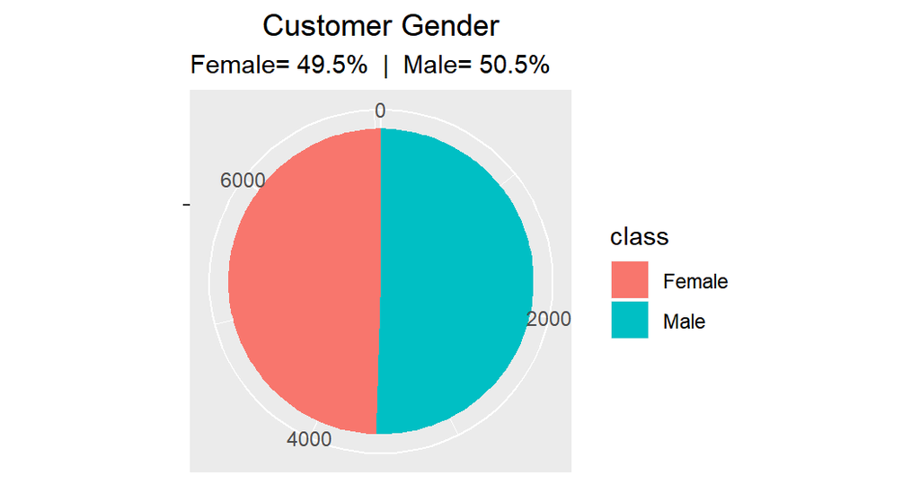

```r
telecomwork1<-telecom
pie <- ggplot(telecomwork1, aes(x = "", fill = factor(gender))) +
  geom_bar(width = 1) +
  theme(axis.line = element_blank(),
        plot.title = element_text(hjust=0.5)) +
  labs(fill="class",
       x=NULL,
       y=NULL,
       title="Customer Gender",
       subtitle="Female= 49.5%  |  Male= 50.5%")

pie + coord_polar(theta = "y", start=0)
```

## Gender and Monthly Charges

*Does one gender pay more monthly charges?*

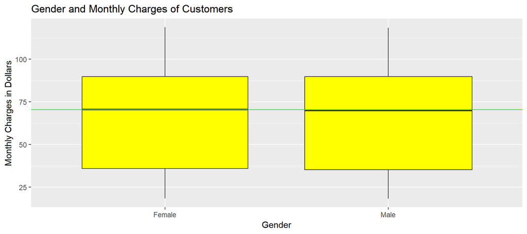

```r
ggplot(telecom,aes(x=gender,y=MonthlyCharges))+
  geom_boxplot(varwidth=T, fill=23) +
  geom_hline(aes(yintercept = median(telecom$MonthlyCharges)), color = "green") +
  labs(x="Gender",y="Monthly Charges in Dollars",title="Gender and Monthly Charges of Customers")
```

The data shows that both male and female monthly costs were about the same with a median of $70.35 represented by the green line. This seems fair and impartial toward a particular sex getting an immense discount.

## Payment

*What is the most common form of payment?*

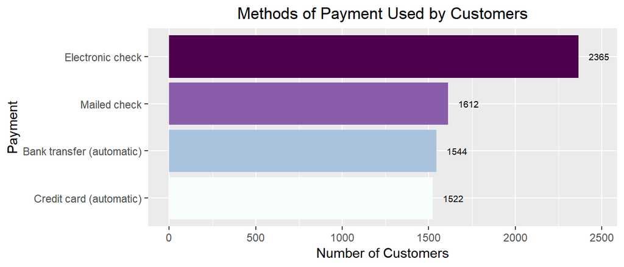

```r
paymethods <- telecom %>%
  group_by(PaymentMethod) %>%
  dplyr::summarize(PaymentMethod_count = n()) %>%
  arrange(desc(PaymentMethod_count))
paymethods$PaymentMethod <- factor(paymethods$PaymentMethod, levels = paymethods$PaymentMethod[order((paymethods$PaymentMethod_count))])
colourCount = length(unique(paymethods$PaymentMethod))
fill_purple <- colorRampPalette(brewer.pal(9,"BuPu"))

paymethods %>%
  filter(PaymentMethod != "NA") %>%
  ggplot(aes(x = PaymentMethod, y = PaymentMethod_count, fill = PaymentMethod)) +
  geom_bar(stat = "identity") +
  coord_flip() +
  geom_text(aes(label = PaymentMethod_count), size = 2.5, color = "black", hjust = -.5) +
  labs(x = "Payment", y = "Number of Customers", title = "Methods of Payment Used by Customers") +
  theme(legend.position = "none", plot.title = element_text(hjust = 0.5)) +
  ylim(0, max(paymethods$PaymentMethod_count + 100)) +
  scale_fill_manual(values = fill_purple(colourCount))
```

```r
prop.table(table(telecom$PaymentMethod))
```

```
##
## Bank transfer (automatic)   Credit card (automatic)
##                 0.2192248                 0.2161011
##          Electronic check              Mailed check
##                 0.3357944                 0.2288797
```

The Most common form of payment was Electronic check accounting for 33.5%. Second most common was Mailed check at 22.9%. Third was Bank transfer (automatic) at 22%. Least common was Credit card (automatic) at 21.6%.

## Monthly charges

*What is the range of monthly charges?*

```r
summary(telecom$MonthlyCharges)
```

```
##    Min. 1st Qu.  Median    Mean 3rd Qu.    Max.
##   18.25   35.50   70.35   64.76   89.85  118.75
```

The monthly charges range from $18.25 to $118.75 per month. The mean/average monthly bill is $64.76. While the median bill is $70.35.

## Senior Citizen’s

*Do senior citizens get a discount? Are there more senior customers?*

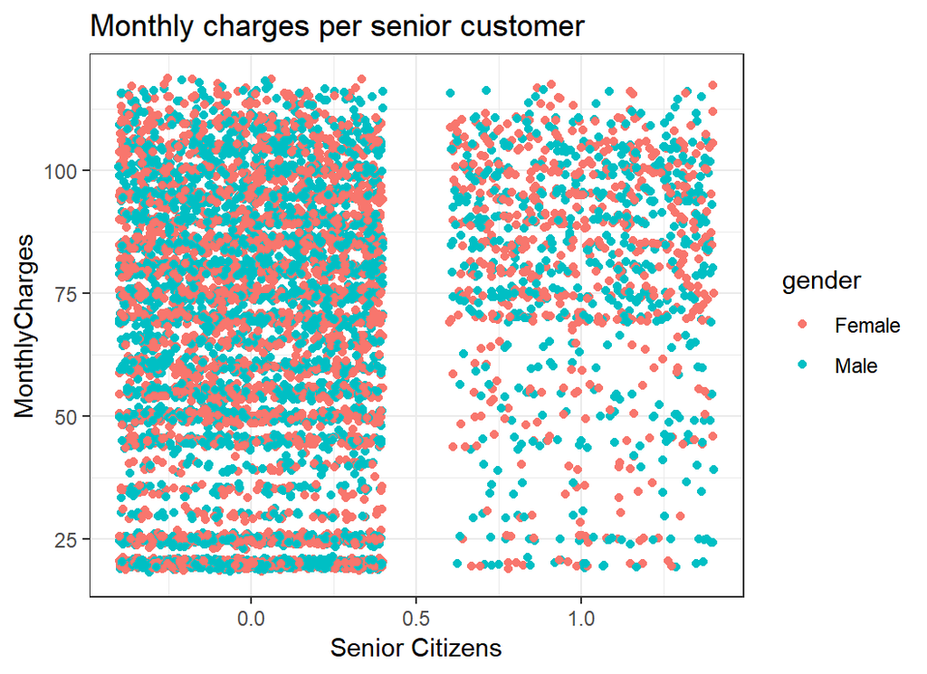

```r
ggplot(telecom,aes(x=SeniorCitizen,y=MonthlyCharges, color=gender))+
  theme_bw()+
  geom_jitter()+
  labs(x="Senior Citizens",y="MonthlyCharges",title="Monthly charges per senior customer")
```

The telecom company seems to have about the same minimum and maximum monthly charges as for the Senior citizens as the regular non senior customers. However, the majority of Senior Citizens seem to be paying above ~$70. Therefore it seems that being a senior does not give a bonus to all customers. We would have to do a bar plot to see the difference between number of senior and non-senior customers to see how many people we have in each group.

[figure not shown]

```r
gendersenir <- telecom %>%
  group_by(SeniorCitizen) %>%
  dplyr::summarize(SeniorCitizen_count = n()) %>%
  arrange(desc(SeniorCitizen_count))
gendersenir$SeniorCitizen <- factor(gendersenir$SeniorCitizen, levels = gendersenir$SeniorCitizen[order((gendersenir$SeniorCitizen_count))])
colourCount = length(unique(gendersenir$SeniorCitizen))
fill_purple <- colorRampPalette(brewer.pal(9,"BuPu"))

gendersenir %>%
  filter(SeniorCitizen != "NA") %>%
  ggplot(aes(x = SeniorCitizen, y = SeniorCitizen_count, fill = SeniorCitizen)) +
  geom_bar(stat = "identity") +
  coord_flip() +
  geom_text(aes(label = SeniorCitizen_count), size = 3, color = "black", hjust = -.5) +
  labs(x = "Payment", y = "Number of Customers", title = "Methods of Payment Used by Customers") +
  theme(legend.position = "none", plot.title = element_text(hjust = 0.5)) +
  ylim(0, max(gendersenir$SeniorCitizen_count + 100)) +
  scale_fill_manual(values = fill_purple(colourCount))
```

There are very few Senior Customers in comparison to non-senior customers. There are more that 5x non senior customers (purple) in comparison to senior customers (white).

## Ecofriendly/ Paperless

*How eco friendly is the brand? Does it have a higher percentage of paperless billing?*

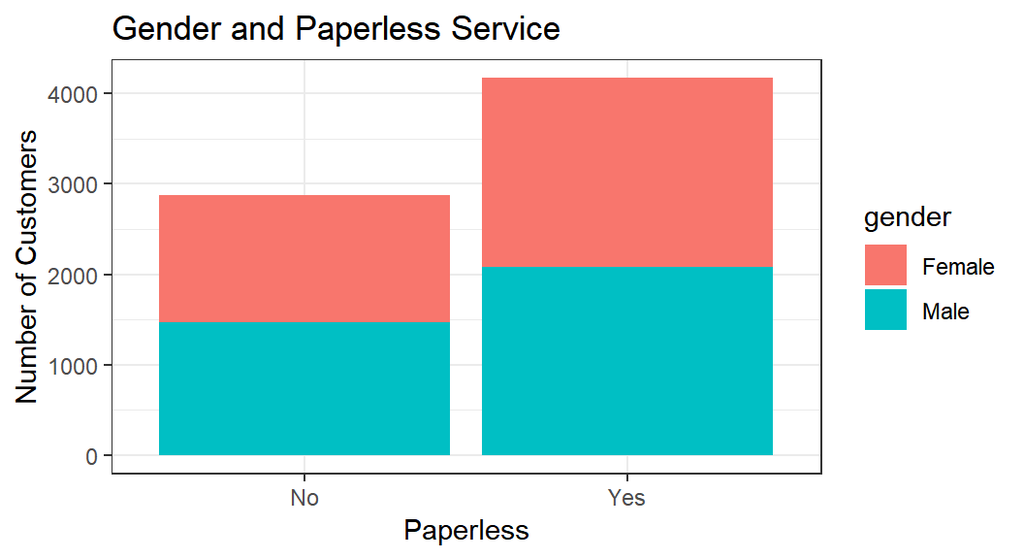

```r
ggplot(telecom,aes(x=PaperlessBilling,fill=gender))+
  theme_bw()+
  geom_bar () +
  labs(x="Paperless",y="Number of Customers",title="Gender and Paperless Service")
```

```r
prop.table(table(telecom$PaperlessBilling))
```

```
##
##        No       Yes
## 0.4077808 0.5922192
```

About 59% of customers choose the paperless route, while 41% still want a paper copy of the bill. This can be improved by giving an incentive to go paperless, which would save the company on stationary supplies such as paper, ink, and postage.

## CustomerTenure

*Which months are critical for keeping the customer?*

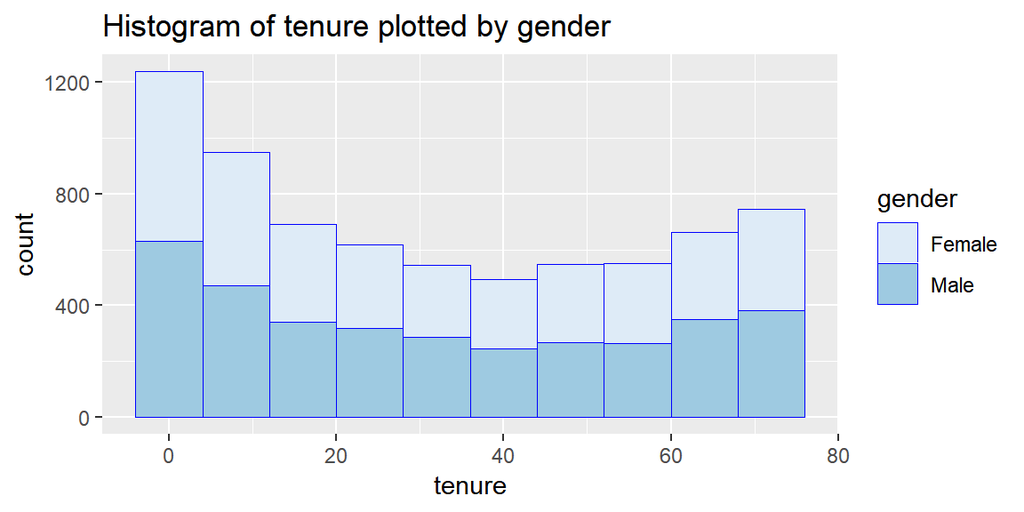

```r
g <- ggplot(telecom, aes(tenure)) + scale_fill_brewer(palette = 1)


g + geom_histogram(aes(fill=gender),
                   bins=10,
                   col="blue",
                   size=.1) +   # change number of bins
  labs(title="Histogram of tenure plotted by gender")
```

There seems to be an equal amount of tenure/retention between male and female customers. It also seems that after 40 months the customer is more likely to stay. However from 0 to 40 months it seems that the customer is likely to churn and the company should focus on retaining their customers during this period.

## Gender and Phoneservice

*Is a particular gender more likely to have a phone service with our company*

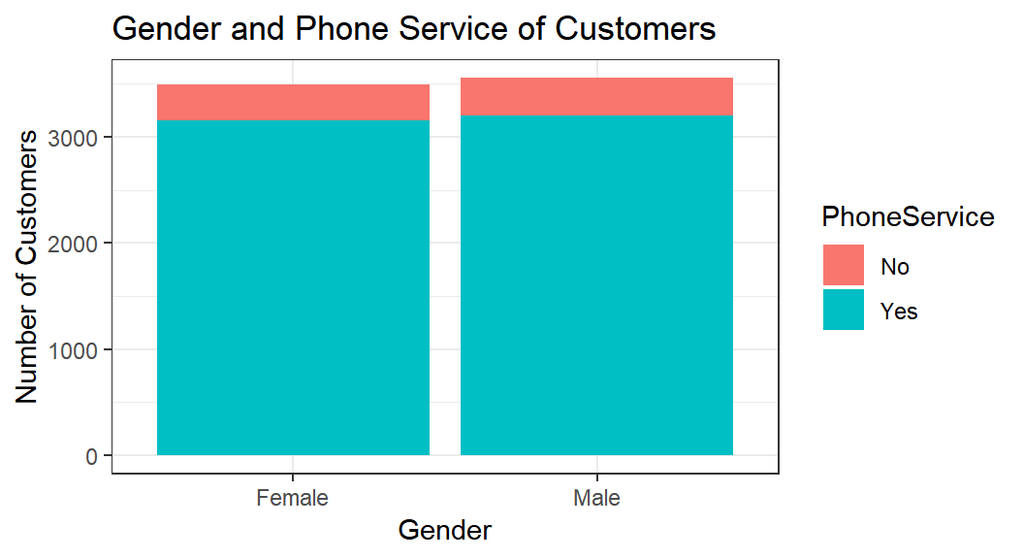

```r
ggplot(telecom,aes(x=gender,fill=PhoneService))+
  theme_bw()+
  geom_bar () +
  labs(x="Gender",y="Number of Customers",title="Gender and Phone Service of Customers")
```

```r
prop.table(table(telecom$gender, telecom$PhoneService))
```

```
##
##                  No        Yes
##   Female 0.04699702 0.44824649
##   Male   0.04983672 0.45491978
```

44.8% women have a phone service with our company while 4.7% women do not. 45.5% male customers have the phone service, while 5% male do not have the phone service.

## Gender and Preferred Type of Payment

*Do more men or women prefer each type of contract? Month-to-month, One year, Two year?*

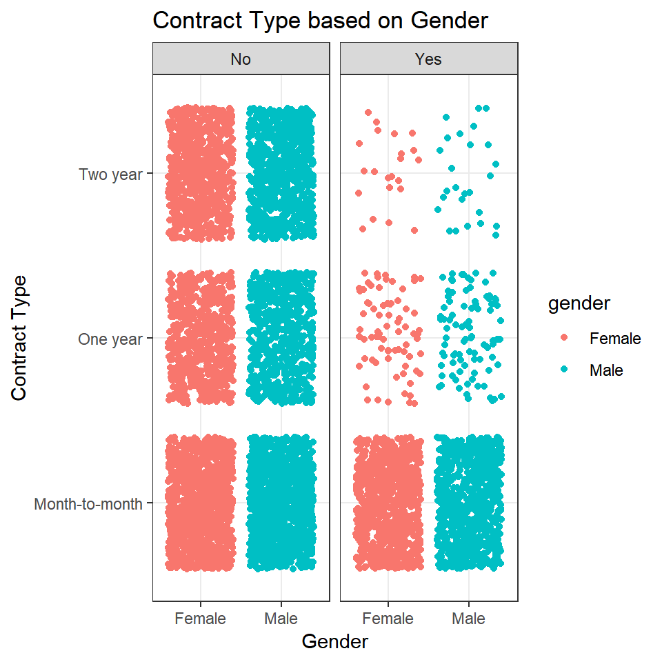

```r
ggplot(telecom,aes(x=gender,y=Contract, color=gender))+
  theme_bw()+
  geom_jitter()+
  facet_grid(.~Churn)+
  labs(x="Gender",y="Contract Type",title="Contract Type based on Gender")
```

There seems to be an equal number of male and women per Contract type. However by adding a Churn statistics to this data we see that the month to month customers where most likely to churn while, One year contractees were less likely to churn and Two year contractees were least likely to churn.

```r
prop.table(table( telecom$Contract))
```

```
##
## Month-to-month       One year       Two year
##      0.5501917      0.2091438      0.2406645
```

The most common contract type is month to month at 55% total, followed by Two year contract at 24%, and least common was one year contract at 21% of total contracts.

```r
prop.table(table(telecom$gender, telecom$Contract))
```

```
##
##          Month-to-month  One year  Two year
##   Female      0.2733210 0.1019452 0.1199773
##   Male        0.2768707 0.1071986 0.1206872
```

The data shows that about 27% male and 27% female have a month to month contract. While 10% female and 11% male have a One year contract. And 12% females and 12% males have a two year contract.

## Internet or Phone sells more

*What is more common phone service or internet service?*

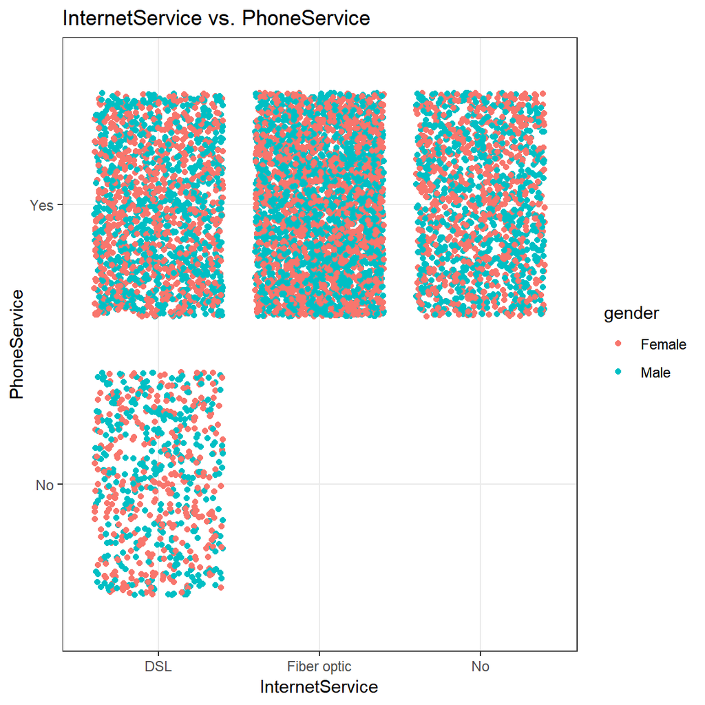

```r
ggplot(telecom,aes(x=InternetService,y=PhoneService,color=gender))+
  theme_bw()+
  geom_jitter() +
  labs(x="InternetService",y="PhoneService",title="InternetService vs. PhoneService")
```

```r
prop.table(table(telecom$InternetService, telecom$PhoneService))
```

```
##
##                       No        Yes
##   DSL         0.09683374 0.24691183
##   Fiber optic 0.00000000 0.43958540
##   No          0.00000000 0.21666903
```

```r
prop.table(table(telecom$InternetService))
```

```
##
##         DSL Fiber optic          No
##   0.3437456   0.4395854   0.2166690
```

```r
prop.table(table( telecom$PhoneService))
```

```
##
##         No        Yes
## 0.09683374 0.90316626
```

78.3% of the customers have Internet service while 90% have phone service. Therefore Phone service is more common. This may lead to the company having to work more on marketing a better way to increase internet sales.

## Internet Sales

*Which types of internet service are most commonly bought?*

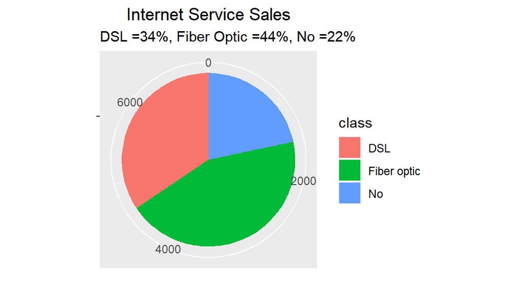

```r
telecomwork<-telecom
pie2 <- ggplot(telecomwork, aes(x = "", fill = factor(InternetService))) +
  geom_bar(width = 1) +
  theme(axis.line = element_blank(),
        plot.title = element_text(hjust=0.5)) +
  labs(fill="class",
       x=NULL,
       y=NULL,
       title="Internet Service Sales",
       subtitle="DSL =34%, Fiber Optic =44%, No =22%")

pie2 + coord_polar(theta = "y", start=0)
```

The internet Service sales indicate that customers chose DSL = 34%, Fiber Optic = 44%, and No internet service = 22% of the times.